# Modeling and prediction for movies

## Setup

### Load packages

```r
library(ggplot2)
library(dplyr)
library(statsr)
```

### Load data

```r
# I changed the working directory using setwd() for it to work.

load("movies.Rdata")
```

## Part 1: Data

The information provided for this assignment came from Rotten Tomatoes and IMDB. For this observational study, the technique used to retreive the data was random sampling. This means that the data that we have in the sample, should be a good representation of the population and not biased. In this case, the population is all of the movies. Thus, we should be able to idendify which independent attributes makes a movie popular, if there are any.

## Part 2: Research question

The question I would like to sudy is the following: Can you predict the IMDB rating at a confidence level of 95% with at least one attribute?

This is an interesting question, because this would mean that I would be able to predict the rattings of a movie before waiting for all of the ratings to come out.

## Part 3: Exploratory data analysis

Some of the data are identified as characters. I will convert those attributes as factors, so I can analyse the frequency of each.

```r
movies$title <- as.factor(movies$title)
movies$director <- as.factor(movies$director)
movies$actor1 <- as.factor(movies$actor1)
movies$actor2 <- as.factor(movies$actor2)
movies$actor3 <- as.factor(movies$actor3)
movies$actor4 <- as.factor(movies$actor4)
movies$actor5 <- as.factor(movies$actor5)
```

For my first exploration, I will use summary which will output some information about each attributes.

```r
summary(movies)
```

```
##                       title            title_type
##  Hairspray               :  2   Documentary : 55
##  Man on Wire             :  2   Feature Film:591
##  Maniac                  :  2   TV Movie    :  5
##  Where the Heart Is      :  2
##  101 Dalmatians          :  1
##  11'09''01 - September 11:  1
##  (Other)                 :641
##                 genre        runtime       mpaa_rating
##  Drama             :305   Min.   : 39.0   G      : 19
##  Comedy            : 87   1st Qu.: 92.0   NC-17  :  2
##  Action & Adventure: 65   Median :103.0   PG     :118
##  Mystery & Suspense: 59   Mean   :105.8   PG-13  :133
##  Documentary       : 52   3rd Qu.:115.8   R      :329
##  Horror            : 23   Max.   :267.0   Unrated: 50
##  (Other)           : 60   NA's   :1
##                               studio    thtr_rel_year  thtr_rel_month
##  Paramount Pictures              : 37   Min.   :1970   Min.   : 1.00
##  Warner Bros. Pictures           : 30   1st Qu.:1990   1st Qu.: 4.00
##  Sony Pictures Home Entertainment: 27   Median :2000   Median : 7.00
##  Universal Pictures              : 23   Mean   :1998   Mean   : 6.74
##  Warner Home Video               : 19   3rd Qu.:2007   3rd Qu.:10.00
##  (Other)                         :507   Max.   :2014   Max.   :12.00
##  NA's                            :  8
##   thtr_rel_day    dvd_rel_year  dvd_rel_month     dvd_rel_day
##  Min.   : 1.00   Min.   :1991   Min.   : 1.000   Min.   : 1.00
##  1st Qu.: 7.00   1st Qu.:2001   1st Qu.: 3.000   1st Qu.: 7.00
##  Median :15.00   Median :2004   Median : 6.000   Median :15.00
##  Mean   :14.42   Mean   :2004   Mean   : 6.333   Mean   :15.01
##  3rd Qu.:21.00   3rd Qu.:2008   3rd Qu.: 9.000   3rd Qu.:23.00
##  Max.   :31.00   Max.   :2015   Max.   :12.000   Max.   :31.00
##                  NA's   :8      NA's   :8        NA's   :8
##   imdb_rating    imdb_num_votes           critics_rating critics_score
##  Min.   :1.900   Min.   :   180   Certified Fresh:135    Min.   :  1.00
##  1st Qu.:5.900   1st Qu.:  4546   Fresh          :209    1st Qu.: 33.00
##  Median :6.600   Median : 15116   Rotten         :307    Median : 61.00
##  Mean   :6.493   Mean   : 57533                          Mean   : 57.69
##  3rd Qu.:7.300   3rd Qu.: 58301                          3rd Qu.: 83.00
##  Max.   :9.000   Max.   :893008                          Max.   :100.00
##
```

[output cut: 25 more lines]

```
##  John Hurt         :  3   Bo Derek           :  2   Length:651
##  John P. Ryan      :  3   Bob Balaban        :  2   Class :character
##  Stephen Tobolowsky:  3   Brenda Fricker     :  2   Mode  :character
##  Alan Alda         :  2   Christina Applegate:  2
##  Alan Arkin        :  2   Colin Firth        :  2
##  (Other)           :625   (Other)            :626
##  NA's              : 13   NA's               : 15
##     rt_url
##  Length:651
##  Class :character
##  Mode  :character
##
##
##
##
```

From this output, I am able to look at the number of unique values for each attribute. We can also see that there are duplicate rows, as there are Titles that are not unique. These will need to be droped.

Also, I will drop the columns title, imdb_url and rt_url because they will not bring any value to my model, as they are unique.

Furthermore, I will drop the attributes that have too many factors, such as the director and actor1-5 attributes because they have more than 600 unique values out of 651 observations. I will do this because they will not help me in predicting the IMDB ratings.

```r
# Remove dupplicates based on the column title
movies <- movies %>%
  distinct(title, .keep_all = TRUE)

# Vector of columns I want to drop
drop_cols <- c("title","imdb_url","rt_url","director","actor1","actor2","actor3","actor4","actor5","studio")

# Drop the columns from the drop_cols vector
movies <- movies %>%
  select(-one_of(drop_cols))
```

Cool! I have dropped 10 attributes.

For the next part of the exploratory data analysis, I will use scatter plots to analyze the linearity of the attributes with the response attribute (imdb_rating).

### Plot 1: Title Types and IMDB Rating

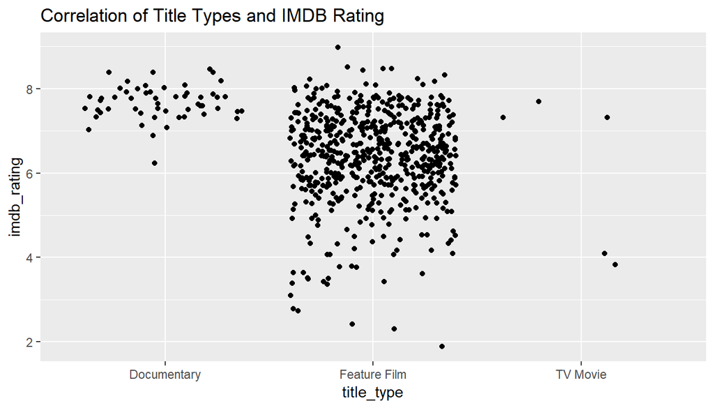

```r
ggplot(data=movies,aes(x=title_type,y=imdb_rating))+
  geom_jitter()+
  geom_smooth(method="lm") +
  labs(title="Correlation of Title Types and IMDB Rating")
```

From this plot, we can see that Documentary type movies have an average high rating compared to the two other types. For this reason, I will create a new variable called “is_documentary”. I will not drop this attribute yet, as we will see in the model building section if this attribute has any value for my model before dropping.

```r
# Create is_documentary variable

movies <- movies %>%
  mutate(is_documentary = ifelse(title_type=="Documentary",1,0))
```

### Plot 2 Theatre release year and IMDB rating

[figure not shown]

```r
# Plot

ggplot(data=movies,aes(x=thtr_rel_year,y=imdb_rating))+
  geom_jitter()+
  labs(title="Scatter Plot IMDB Rating and Theatre Release Year")+
  geom_smooth(method="lm")
```

From looking at this graph, we can see that the data is in a fan shape. Also, the linear function doesn’t see to me positive or negative. For this reason, I will also look at the residuals plot to see if this data would be valid by looking at the constant variance of the residuals.

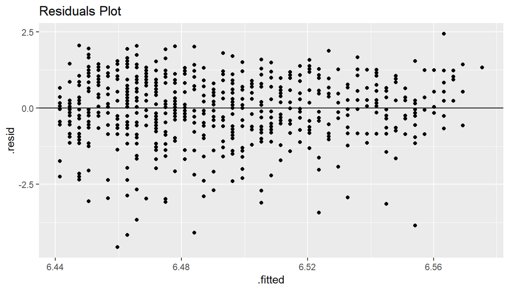

```r
m1 <- lm(imdb_rating~thtr_rel_year,data=movies)
ggplot(data=m1, aes(x=.fitted,y=.resid))+
  geom_point()+
  geom_hline(yintercept = 0)+
  labs(title="Residuals Plot")
```

The constant variance seems to hold for this attribute. Thus, I will keep it for now, and assess it later when I build the model.

### Plot 3: Critics Score and IMDB Rating

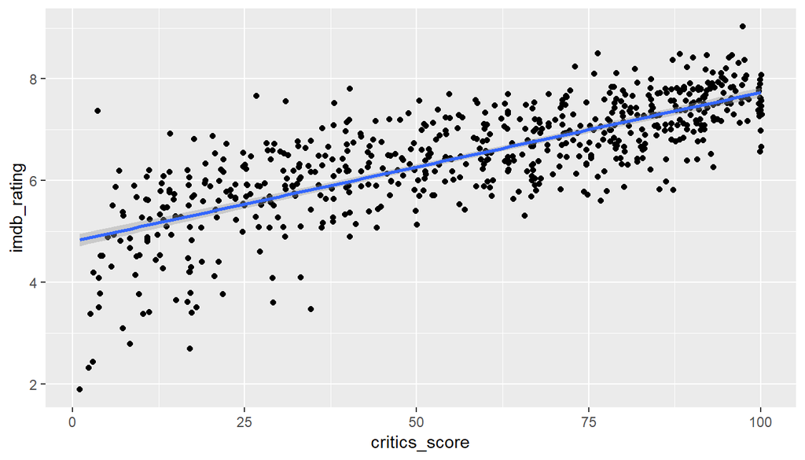

```r
ggplot(data=movies,aes(x=critics_score,y=imdb_rating))+
  geom_jitter()+
  geom_smooth(method="lm")
```

From looking at this model, we see a positive linear relationship between both variables. There is a fan looking shape though, so I would like to confirm with the residuals plot to make sure this would be a valid attribute for my model.

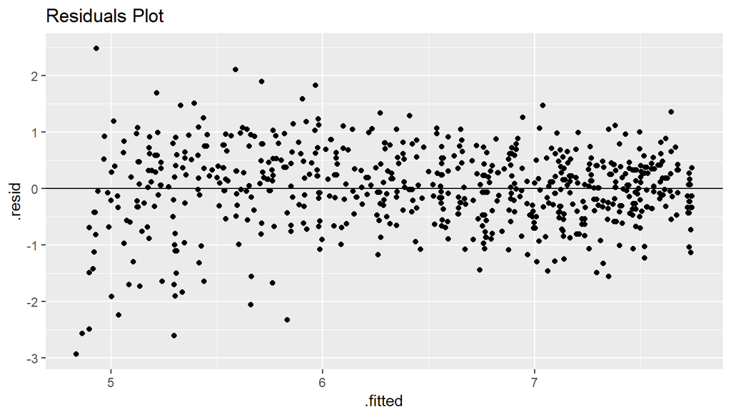

```r
m2 <- lm(imdb_rating ~ critics_score,data=movies)

ggplot(data=m2,aes(x=.fitted,y=.resid))+
  geom_jitter()+
  geom_hline(yintercept = 0)+
  labs(title="Residuals Plot")
```

From this plot, it seems to still have a bit of heteroscedasticity, because there is more variance on the left than the right. Having this said, I don’t want to discard the model, because according to Heteroscedasticity in Regression Analysis by Jim, “heteroscedasticity doesn’t cause bias in the coefficient estimates, it does make them less precise” [1]. Therefore, I will keep it for now and maybe assess it later.

[1] http://statisticsbyjim.com/regression/heteroscedasticity-regression/

### Plot 4: Runtime and IMDB Rating

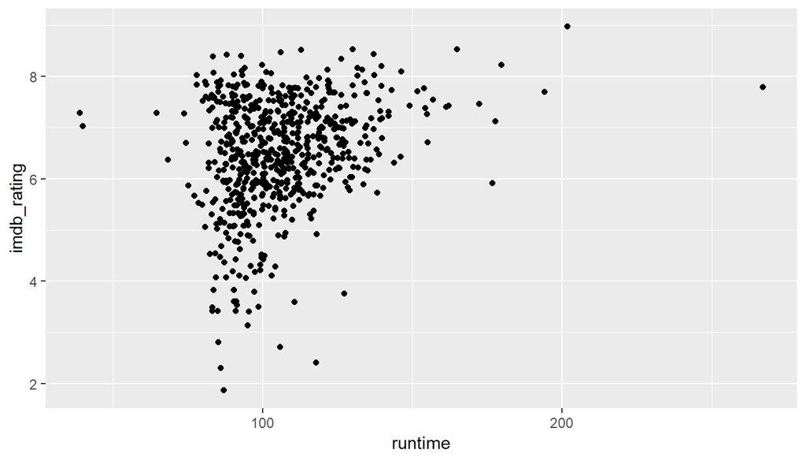

```r
ggplot(data=movies,aes(x=runtime,y=imdb_rating))+
  geom_jitter()
```

The runtime attribute is a good example to showcase that it doesn’t have a linear relationship with the IMDB score, so I will drop this one.

### Results after my exploration

I proceeded with the previous technique using scatter plots and residual plots to assess all of the other variables.

The binary attributes [best_pic_in, best_actor_win, best_actress_win, best_dir_win, top200_box] all demonstrated a linear relationship on the “yes” option. Therefore, I will create another variable which will simply have a “1” if the movie has a winner in either category.

Furthermore, according to the summary call that I had done previously, those binary attributes all had imbalanced classes ranging from 7 “yes” to 93 “yes” out of ~ 650 rows. Therefore, it is best to drop them and keep the new attribute best_something.

```r
# Create new column best_something
movies <- movies %>%
  mutate(best_something = ifelse(best_pic_win=="yes",1,ifelse(best_actor_win=="yes",1,ifelse(best_actress_win=="yes",1,ifelse(best_dir_win=="yes",1,ifelse(top200_box=="yes",1,0))))))
```

Now, we can drop the variables that didn’t have a linear relationship with imdb_rating and the others that I have indicated to drop.

```r
# Create a vector of columns to drop
drop_cols2 <- c("genre","runtime","thtr_rel_month","thtr_rel_day","dvd_rel_year","dvd_rel_month","dvd_rel_day","best_pic_win","best_actor_win","best_actress_win","best_dir_win","top200_box")

# Drop them from movies
movies <- movies %>%
  select(-one_of(drop_cols2))
```

Wow! Down to 11 possible good variables to build my model.

```r
# Move the response variable to the last column
movies <- movies %>%
  select(-imdb_rating,imdb_rating)
```

## Part 4: Modeling

### Full model

I will start using the full model, then use the p-values to withdraw insignificant variables from my model so I end with the simplest model offering the best predictive power.

```r
# First model, iteration 1
full_model <- lm(imdb_rating ~ title_type + mpaa_rating + imdb_num_votes + critics_rating + critics_score + audience_rating + audience_score + best_pic_nom + is_documentary + best_something, data=movies)
summary(full_model)
```

```
##
## Call:
## lm(formula = imdb_rating ~ title_type + mpaa_rating + imdb_num_votes +
##     critics_rating + critics_score + audience_rating + audience_score +
##     best_pic_nom + is_documentary + best_something, data = movies)
##
## Residuals:
##      Min       1Q   Median       3Q      Max
## -2.36051 -0.19706  0.03631  0.25201  1.15615
##
## Coefficients: (1 not defined because of singularities)
##                          Estimate Std. Error t value Pr(>|t|)
## (Intercept)             2.975e+00  2.030e-01  14.655  < 2e-16 ***
## title_typeFeature Film -2.157e-01  8.643e-02  -2.495   0.0128 *
## title_typeTV Movie     -4.496e-01  2.193e-01  -2.050   0.0407 *
## mpaa_ratingNC-17        7.442e-02  3.447e-01   0.216   0.8291
## mpaa_ratingPG           3.478e-02  1.148e-01   0.303   0.7621
## mpaa_ratingPG-13        1.160e-01  1.151e-01   1.008   0.3136
## mpaa_ratingR            1.933e-01  1.097e-01   1.762   0.0785 .
## mpaa_ratingUnrated      1.512e-01  1.321e-01   1.144   0.2529
## imdb_num_votes          9.976e-07  1.954e-07   5.106 4.36e-07 ***
## critics_ratingFresh     1.405e-01  5.747e-02   2.445   0.0148 *
## critics_ratingRotten    4.236e-01  9.209e-02   4.600 5.11e-06 ***
## critics_score           1.629e-02  1.554e-03  10.484  < 2e-16 ***
## audience_ratingUpright -3.362e-01  7.393e-02  -4.548 6.49e-06 ***
## audience_score          4.013e-02  2.107e-03  19.045  < 2e-16 ***
## best_pic_nomyes        -3.570e-02  1.094e-01  -0.326   0.7443
## is_documentary                 NA         NA      NA       NA
## best_something          1.023e-01  4.265e-02   2.398   0.0168 *
## ---
## Signif. codes:  0 '***' 0.001 '**' 0.01 '*' 0.05 '.' 0.1 ' ' 1
##
## Residual standard error: 0.4618 on 631 degrees of freedom
## Multiple R-squared:  0.8235, Adjusted R-squared:  0.8193
## F-statistic: 196.3 on 15 and 631 DF,  p-value: < 2.2e-16
```

mpaa_ratingNC-17 has the highest p-value, but it is part of the other mpaa ratings, so I cannot remove it. best_pic_nomyes has a very high value, which indicate that it doesn’t have any significance to my model, so I should drop it.

```r
# Model iteration 2
# Remove best_pic_nom
full_model <- lm(imdb_rating ~ title_type + mpaa_rating + imdb_num_votes + critics_rating + critics_score + audience_rating + audience_score + is_documentary + best_something, data=movies)
summary(full_model)
```

```
##
## Call:
## lm(formula = imdb_rating ~ title_type + mpaa_rating + imdb_num_votes +
##     critics_rating + critics_score + audience_rating + audience_score +
##     is_documentary + best_something, data = movies)
##
## Residuals:
##      Min       1Q   Median       3Q      Max
## -2.36178 -0.19447  0.03616  0.25433  1.15541
##
## Coefficients: (1 not defined because of singularities)
##                          Estimate Std. Error t value Pr(>|t|)
## (Intercept)             2.980e+00  2.024e-01  14.726  < 2e-16 ***
## title_typeFeature Film -2.168e-01  8.631e-02  -2.511   0.0123 *
## title_typeTV Movie     -4.511e-01  2.191e-01  -2.059   0.0399 *
## mpaa_ratingNC-17        7.517e-02  3.444e-01   0.218   0.8273
## mpaa_ratingPG           3.293e-02  1.146e-01   0.287   0.7739
## mpaa_ratingPG-13        1.144e-01  1.149e-01   0.996   0.3198
## mpaa_ratingR            1.922e-01  1.096e-01   1.754   0.0799 .
## mpaa_ratingUnrated      1.505e-01  1.320e-01   1.140   0.2547
## imdb_num_votes          9.857e-07  1.918e-07   5.140 3.67e-07 ***
## critics_ratingFresh     1.423e-01  5.718e-02   2.488   0.0131 *
## critics_ratingRotten    4.248e-01  9.195e-02   4.620 4.66e-06 ***
## critics_score           1.627e-02  1.552e-03  10.486  < 2e-16 ***
## audience_ratingUpright -3.354e-01  7.383e-02  -4.543 6.64e-06 ***
## audience_score          4.008e-02  2.101e-03  19.079  < 2e-16 ***
## is_documentary                 NA         NA      NA       NA
## best_something          1.004e-01  4.223e-02   2.377   0.0178 *
## ---
## Signif. codes:  0 '***' 0.001 '**' 0.01 '*' 0.05 '.' 0.1 ' ' 1
##
## Residual standard error: 0.4614 on 632 degrees of freedom
## Multiple R-squared:  0.8235, Adjusted R-squared:  0.8196
## F-statistic: 210.6 on 14 and 632 DF,  p-value: < 2.2e-16
```

From this summary output, we can see that all mpaa_ratings have non-significant p-values, so I can remove that variable from my model.

```r
# Model iteration 3
# Remove mpaa_rating
full_model <- lm(imdb_rating ~ title_type + imdb_num_votes + critics_rating + critics_score + audience_rating + audience_score + is_documentary + best_something, data=movies)
summary(full_model)
```

```
##
## Call:
## lm(formula = imdb_rating ~ title_type + imdb_num_votes + critics_rating +
##     critics_score + audience_rating + audience_score + is_documentary +
##     best_something, data = movies)
##
## Residuals:
##      Min       1Q   Median       3Q      Max
## -2.31204 -0.18270  0.02992  0.25624  1.21051
##
## Coefficients: (1 not defined because of singularities)
##                          Estimate Std. Error t value Pr(>|t|)
## (Intercept)             3.132e+00  1.684e-01  18.603  < 2e-16 ***
## title_typeFeature Film -2.065e-01  7.388e-02  -2.795  0.00535 **
## title_typeTV Movie     -4.038e-01  2.194e-01  -1.841  0.06614 .
## imdb_num_votes          1.015e-06  1.899e-07   5.342 1.28e-07 ***
## critics_ratingFresh     1.361e-01  5.743e-02   2.370  0.01807 *
## critics_ratingRotten    4.080e-01  9.227e-02   4.422 1.15e-05 ***
## critics_score           1.619e-02  1.556e-03  10.403  < 2e-16 ***
## audience_ratingUpright -3.294e-01  7.422e-02  -4.437 1.07e-05 ***
## audience_score          3.990e-02  2.111e-03  18.899  < 2e-16 ***
## is_documentary                 NA         NA      NA       NA
## best_something          9.300e-02  4.233e-02   2.197  0.02838 *
## ---
## Signif. codes:  0 '***' 0.001 '**' 0.01 '*' 0.05 '.' 0.1 ' ' 1
##
## Residual standard error: 0.4641 on 637 degrees of freedom
## Multiple R-squared:   0.82,  Adjusted R-squared:  0.8175
## F-statistic: 322.5 on 9 and 637 DF,  p-value: < 2.2e-16
```

## Part 5: Prediction

It’s time to predict our model! I really enjoyed the movie deadpool, so I will use this movie for my prediction.

```r
new_movie <- data.frame(title_type=c("Feature Film"),imdb_num_votes=c(777237),critics_rating=c("Certified Fresh"),critics_score=c(84),audience_rating=c("Upright"),audience_score=c(90),is_documentary=c(0),best_something=c(0))

predict(full_model,newdata=new_movie,interval='prediction')
```

```
##        fit      lwr      upr
## 1 8.335805 7.391861 9.279749
```

This model predicted that with a 95% confidence, that the movie Deadpool will have a rating between 7.39 to 9.28.

This is very interesting, because with a prediction of 8.33, the movie’s imdb score is actually 8. Verry Close!

## Part 6: Conclusion

Some ideas for possible future, would be to reduce my model to a simpler model by looking at the adjusted R squared, and to see if dropping other variables, even if they are indicated as significant, would have much impact on my model.

All in all, I learnt how to evaluate the attributes in my data set, so that I can focus on attributes that have more impact. This is important, because at first, I would of tried to do some feature engineering on attributes that could of had no significance, which would of been a waste of time.